# MSDS 6372 Project 2: Modeling Bank Customer Term Deposit Subscription Behavior to Improve Marketing Efforts

Jonathan Rocha & Tracy Dower

## Data Preparation

```r
### Correct missing or nonsense values

dim(bank_full) # 45211 rows with 17 columns
```

```
## [1] 45211    17
```

```r
sum(is.na(bank_full)) #0 rows with actual MISSING values
```

```
## [1] 0
```

```r
sapply(bank_full, function(col) any(col == "unknown"))
```

```
##        age        job    marital  education    default    balance    housing
##      FALSE       TRUE      FALSE       TRUE      FALSE      FALSE      FALSE
##       loan    contact        day      month   duration   campaign      pdays
##      FALSE       TRUE      FALSE      FALSE      FALSE      FALSE      FALSE
##   previous   poutcome Subscribed
##      FALSE       TRUE      FALSE
```

```r
# unknown used as a placeholder for missing data in 4 columns
sapply(bank_full[c("job", "education", "contact", "poutcome")], function(col) sum(col == "unknown"))
```

```
##       job education   contact  poutcome
##       288      1857     13020     36959
```

```r
# job education  contact poutcome
# 288   1857   13020   36959

# assuming the unknown's are Missing Completely At Random (MCAR)
bank_full[c("job", "education", "contact", "poutcome")] <-
 lapply(bank_full[c("job", "education", "contact", "poutcome")],
     function(col) ifelse(col == "unknown", NA, col))
sapply(bank_full[c("job", "education", "contact", "poutcome")], function(col) sum(is.na(col)))
```

```
##       job education   contact  poutcome
##       288      1857     13020     36959
```

```r
# Function to impute the missing values using the MODE for each of those 4 columns:
my_impute_missing <- function(x) {
 x[is.na(x)] <- names(which.max(table(x)))
 return(x)
}
bank_full[c("job", "education", "contact", "poutcome")] <-lapply(bank_full[c("job", "education", "contact", "poutcome")], my_impute_missing)
sapply(bank_full[c("job", "education", "contact", "poutcome")], function(col) sum(is.na(col)))
```

```
##       job education   contact  poutcome
##         0         0         0         0
```

# Exploratory Data Analysis

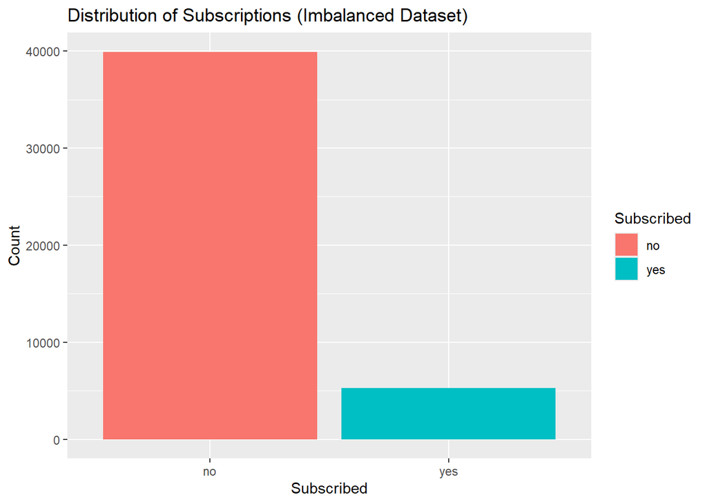

```r
library(ggplot2)
ggplot(bank_full, aes(x=Subscribed, fill=Subscribed)) +
 geom_bar() +
   scale_fill_manual(values = c("no" = "#F8766D", "yes" = "#00BFC4")) + # matches ggplot2 default palette
 labs(title="Distribution of Subscriptions (Imbalanced Dataset)", x="Subscribed", y="Count")
```

Strong class imbalance: most customers said “no” to subscribing, and only a small fraction said “yes.”

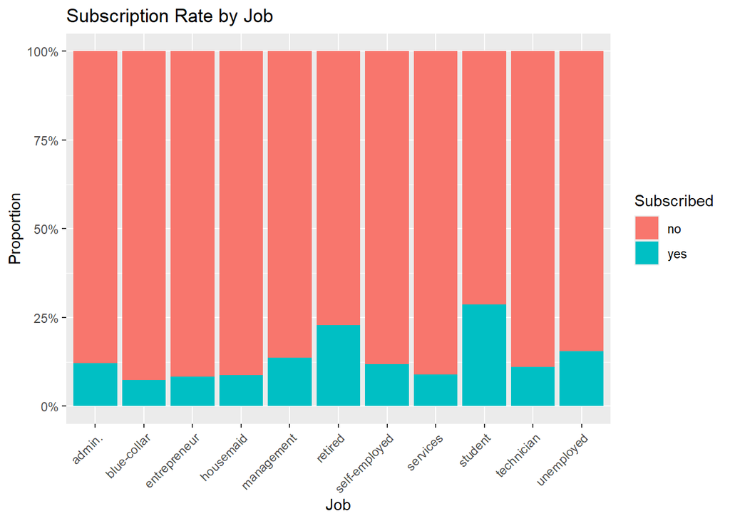

```r
ggplot(bank_full, aes(x=job, fill=Subscribed)) +
 geom_bar(position="fill") +
 labs(title="Subscription Rate by Job", x="Job", y="Proportion") +
 scale_y_continuous(labels=scales::percent) +
 theme(axis.text.x=element_text(angle=45, hjust=1))
```

Subscriptions by Job: Students and retired individuals have the highest subscription rates (longest turquoise bars). Blue-collar, entrepreneur, and services roles have low subscription rates.

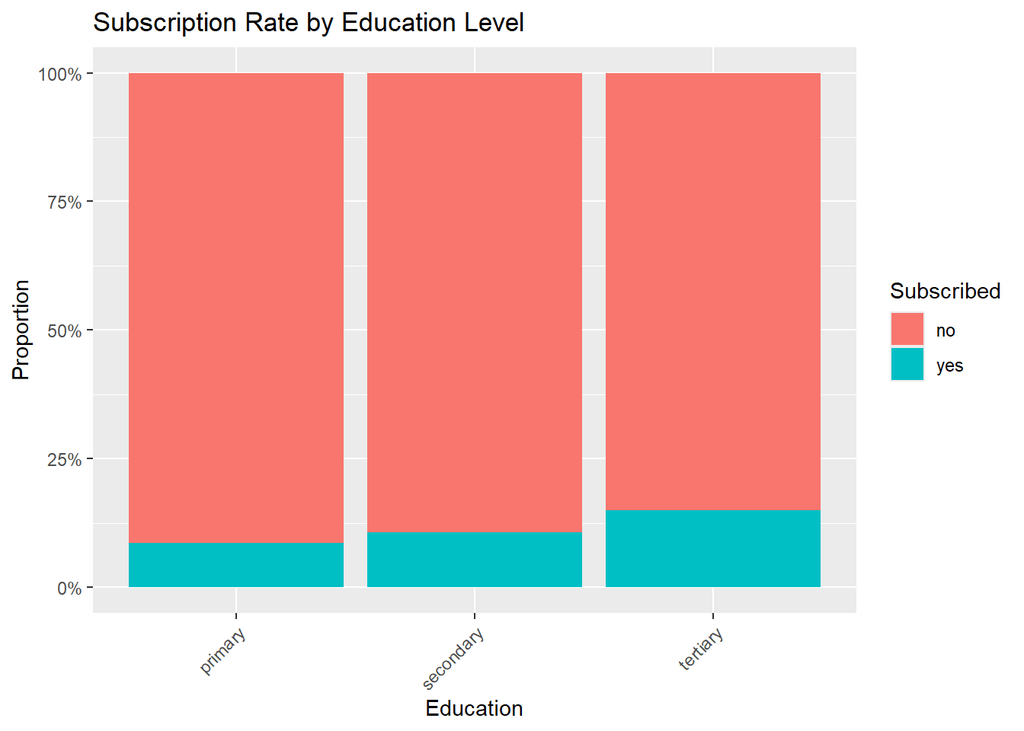

```r
ggplot(bank_full, aes(x=education, fill=Subscribed)) +
 geom_bar(position="fill") +
 labs(title="Subscription Rate by Education Level", x="Education", y="Proportion") +
 scale_y_continuous(labels=scales::percent) +
 theme(axis.text.x=element_text(angle=45, hjust=1))
```

Subscriptions by Level of Education Tertiary education has the highest subscription rate. Primary education has the lowest. Secondary is in between.

This suggests education level is a strong predictor of campaign success. Later, we must explore the interaction between education level and balance – because probably the higher educated people have higher balances.

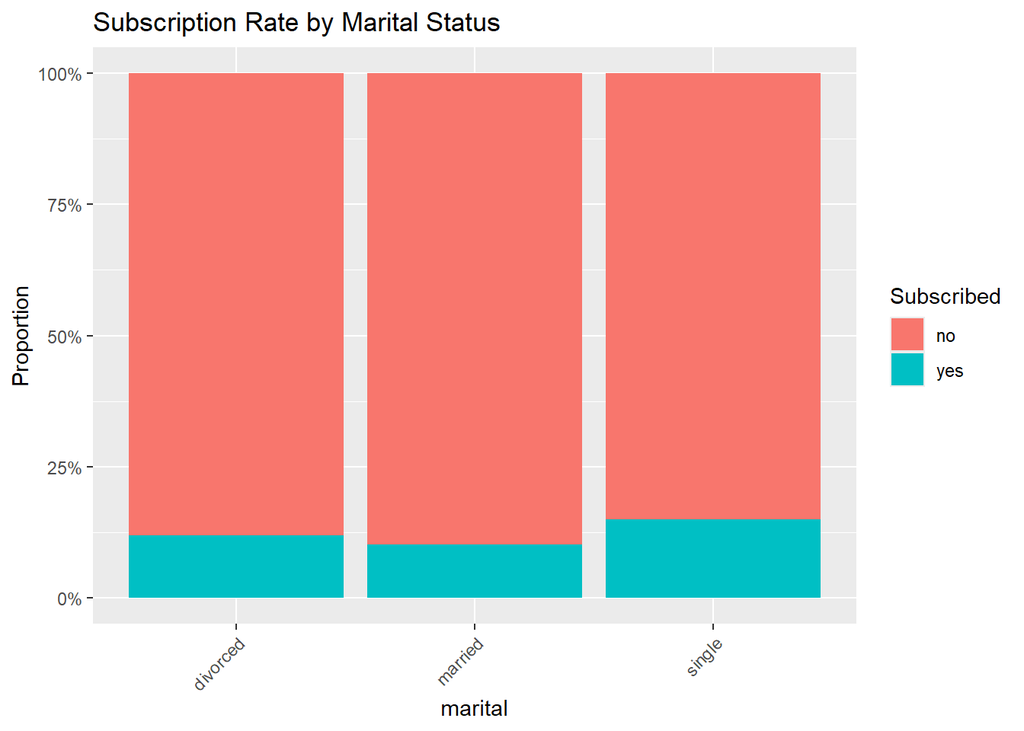

```r
ggplot(bank_full, aes(x=marital, fill=Subscribed)) +
 geom_bar(position="fill") +
 labs(title="Subscription Rate by Marital Status", x="marital", y="Proportion") +
 scale_y_continuous(labels=scales::percent) +
 theme(axis.text.x=element_text(angle=45, hjust=1))
```

Single customers have the highest subscription rate (tallest turquoise bar) Married customers have the lowest subscription rate. Divorced customers are in between.

Single people may be more receptive to the campaign, perhaps due to lifestyle, finances, or free time. Later, we should see how this effect fairs when moderated by balance.

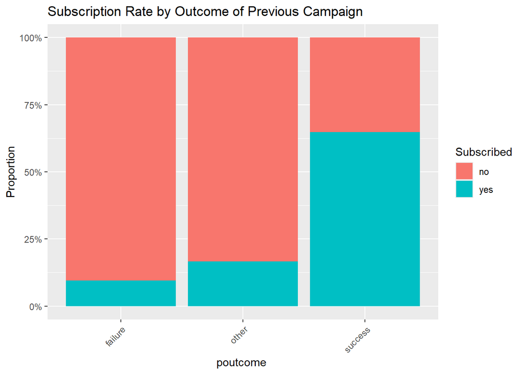

```r
ggplot(bank_full, aes(x=poutcome , fill=Subscribed)) +
 geom_bar(position="fill") +
 labs(title="Subscription Rate by Outcome of Previous Campaign ", x="poutcome ", y="Proportion") +
 scale_y_continuous(labels=scales::percent) +
 theme(axis.text.x=element_text(angle=45, hjust=1))
```

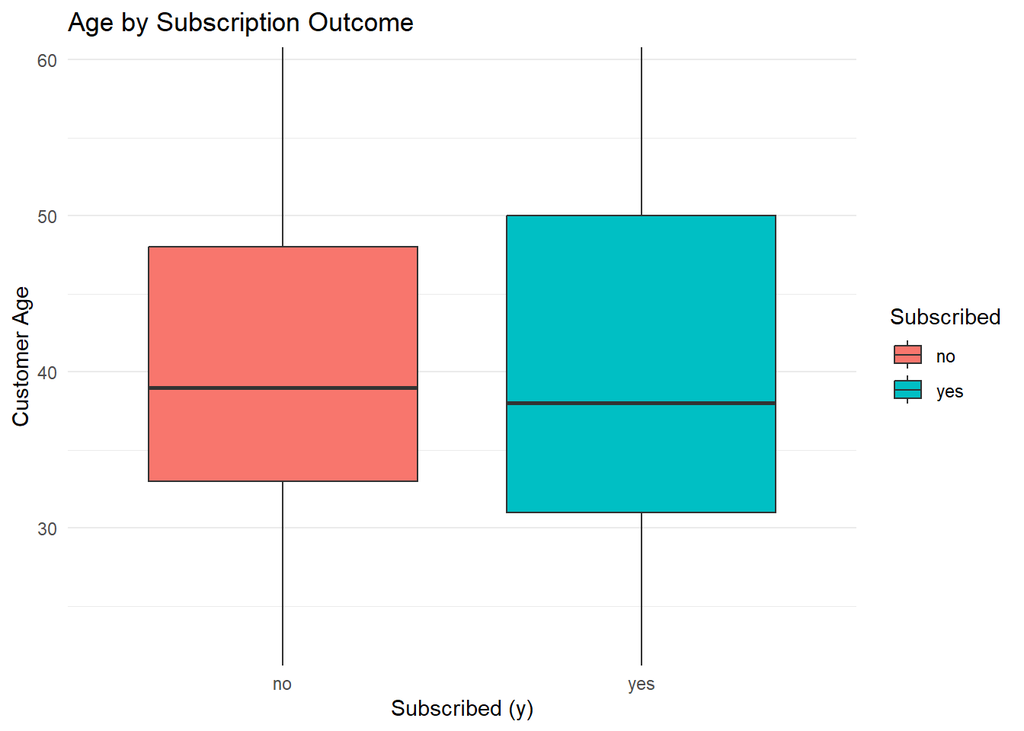

```r
ggplot(bank_full, aes(x=Subscribed, y=age, fill=Subscribed)) +
 geom_boxplot(outlier.shape=NA) +
 coord_cartesian(ylim=quantile(bank_full$age, c(0.01, 0.95)))+# adjust y-axis so extreme outliers don't dominate the plot
 labs(title="Age by Subscription Outcome", x="Subscribed (y)", y="Customer Age") +
 theme_minimal()
```

Median age is similar for both groups (around late 30s). The “yes” group has a slightly wider age range, skewed a bit older. Both groups include young and older customers — age alone may not be decisive.

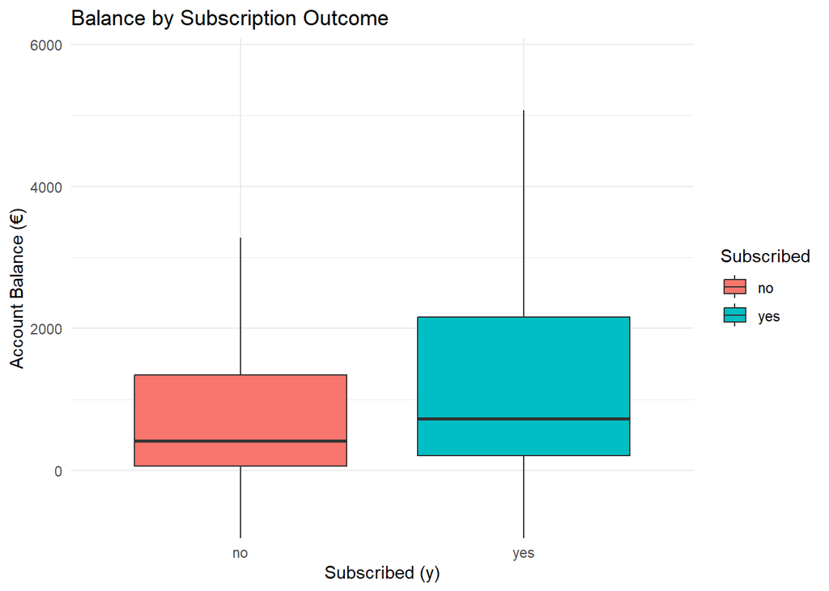

```r
ggplot(bank_full, aes(x=Subscribed, y=balance, fill=Subscribed)) +
 geom_boxplot(outlier.shape=NA) +
 coord_cartesian(ylim=quantile(bank_full$balance, c(0.01, 0.95)))+# adjust y-axis so extreme outliers don't dominate the plot
 labs(title="Balance by Subscription Outcome", x="Subscribed (y)", y="Account Balance (€)") +
 theme_minimal()
```

Customers who said “yes” have a higher median balance than those who said “no”. The interquartile range (box width) is wider for “yes”, suggesting more variation. A few very high balances exist in both groups (we trimmed extreme outliers for clarity). Customers with higher account balances are more likely to subscribe. Balance is a useful predictor.

# Train/Test Split

```r
# MUST come AFTER data cleanup and EDA
library(caret)
set.seed(123)
bank_full$Subscribed <- factor(bank_full$Subscribed, levels=c("no", "yes")) # Do this BEFORE the train/test split then we don't have to constantly redo it.
split_index <- createDataPartition(bank_full$Subscribed, p = 0.8, list = FALSE)
bank_full$Set <- "Validation"
bank_full$Set[split_index] <- "Training"
training <- bank_full[bank_full$Set == "Training", ]
validation <- bank_full[bank_full$Set == "Validation", ]
```

# Objective 1: Perform Additive Logistric Regression

• Display the ability to PERFORM EDA and BUILD A LOGISTIC REGRESSION MODEL for INTERPRETATION purposes using the training data. • Objective 1 is for interpretable modeling, not predictive performance. Prof. Turner says: • Focus on interpreting coefficients, CIs, statistical vs practical significance • Use ONLY EDA and intuition to build up your model – no feature selection • interpret the regression coefficients and confidence intervals for relevant variables • Comment on the practical vs statistical significance of factors we deem important • Do NOT go crazy with extremely fancy models – let EDA, feature selection, and/or overall intuition guide you. • DO NOT use interactions in OBJECTIVE1 models • Demonstrate our ability to interpret the regression coefficients!!!! • USE EFFECTS PLOTS in addition to a thorough interpretation of coefficients. • For deciding between models during training, JUST USE THE AIC!

```r
obj1_model1  <- glm(Subscribed~age+job+education+marital+balance+contact+month+campaign+pdays+previous+poutcome, data=training, family="binomial")
obj1_model2  <- glm(Subscribed~age+job+education+marital+contact+month+campaign+poutcome, data=training, family="binomial")
dropDeviance_2_vs_1 <- anova(obj1_model1, obj1_model2, test = "Chisq")
dropDeviance_2_vs_1  # ALL the features are STATISTICALLY SIGNIFICNATLY better than just the more powerful features
```

```
## Analysis of Deviance Table
##
## Model 1: Subscribed ~ age + job + education + marital + balance + contact +
##     month + campaign + pdays + previous + poutcome
## Model 2: Subscribed ~ age + job + education + marital + contact + month +
##     campaign + poutcome
##   Resid. Df Resid. Dev Df Deviance  Pr(>Chi)
## 1     36136      22327
## 2     36139      22349 -3  -22.137 6.109e-05 ***
## ---
## Signif. codes:  0 '***' 0.001 '**' 0.01 '*' 0.05 '.' 0.1 ' ' 1
```

```r
AIC(obj1_model1)
```

```
## [1] 22395.26
```

```r
summary(obj1_model1)
```

```
##
## Call:
## glm(formula = Subscribed ~ age + job + education + marital +
##     balance + contact + month + campaign + pdays + previous +
##     poutcome, family = "binomial", data = training)
##
## Coefficients:
##                      Estimate Std. Error z value Pr(>|z|)
## (Intercept)        -1.752e+00  1.466e-01 -11.949  < 2e-16 ***
## age                 2.932e-03  2.155e-03   1.361 0.173556
## jobblue-collar     -1.609e-01  7.150e-02  -2.250 0.024447 *
## jobentrepreneur    -2.624e-01  1.249e-01  -2.101 0.035653 *
## jobhousemaid       -1.710e-01  1.314e-01  -1.301 0.193119
## jobmanagement      -3.610e-02  7.262e-02  -0.497 0.619156
## jobretired          5.040e-01  9.572e-02   5.266 1.40e-07 ***
## jobself-employed   -4.918e-02  1.111e-01  -0.443 0.658053
## jobservices        -7.700e-02  8.220e-02  -0.937 0.348904
## jobstudent          6.488e-01  1.090e-01   5.952 2.65e-09 ***
## jobtechnician      -3.939e-02  6.848e-02  -0.575 0.565083
## jobunemployed       3.271e-01  1.070e-01   3.058 0.002230 **
## educationsecondary  1.294e-01  6.206e-02   2.085 0.037044 *
## educationtertiary   3.848e-01  7.313e-02   5.262 1.42e-07 ***
## maritalmarried     -1.982e-01  5.770e-02  -3.435 0.000593 ***
## maritalsingle       1.840e-01  6.546e-02   2.810 0.004951 **
## balance             2.183e-05  5.018e-06   4.351 1.36e-05 ***
## contacttelephone   -8.472e-02  7.386e-02  -1.147 0.251399
## monthaug           -4.941e-01  7.564e-02  -6.532 6.48e-11 ***
## monthdec            7.318e-01  1.809e-01   4.046 5.22e-05 ***
## monthfeb           -2.763e-01  8.388e-02  -3.294 0.000989 ***
## monthjan           -9.569e-01  1.192e-01  -8.031 9.70e-16 ***
## monthjul           -5.890e-01  7.518e-02  -7.834 4.73e-15 ***
## monthjun           -5.540e-01  7.784e-02  -7.117 1.10e-12 ***
## monthmar            1.274e+00  1.218e-01  10.456  < 2e-16 ***
## monthmay           -1.037e+00  6.797e-02 -15.253  < 2e-16 ***
## monthnov           -8.309e-01  8.480e-02  -9.799  < 2e-16 ***
## monthoct            8.833e-01  1.076e-01   8.212  < 2e-16 ***
## monthsep            6.149e-01  1.198e-01   5.133 2.86e-07 ***
## campaign           -9.542e-02  9.503e-03 -10.041  < 2e-16 ***
## pdays               2.633e-04  1.954e-04   1.348 0.177696
## previous            7.602e-03  6.054e-03   1.256 0.209232
## poutcomeother       3.465e-01  8.528e-02   4.063 4.84e-05 ***
## poutcomesuccess     2.412e+00  7.170e-02  33.635  < 2e-16 ***
## ---
## Signif. codes:  0 '***' 0.001 '**' 0.01 '*' 0.05 '.' 0.1 ' ' 1
##
## (Dispersion parameter for binomial family taken to be 1)
##
##     Null deviance: 26108  on 36169  degrees of freedom
## Residual deviance: 22327  on 36136  degrees of freedom
## AIC: 22395
##
## Number of Fisher Scoring iterations: 5
```

```r
confint(obj1_model1)
```

```
##                            2.5 %        97.5 %
## (Intercept)        -2.039648e+00 -1.464966e+00
## age                -1.296973e-03  7.149289e-03
## jobblue-collar     -3.008611e-01 -2.050534e-02
## jobentrepreneur    -5.119552e-01 -2.197970e-02
## jobhousemaid       -4.334844e-01  8.195239e-02
## jobmanagement      -1.780521e-01  1.066734e-01
## jobretired          3.160759e-01  6.913359e-01
## jobself-employed   -2.697971e-01  1.660171e-01
## jobservices        -2.388287e-01  8.351050e-02
## jobstudent          4.339509e-01  8.614149e-01
## jobtechnician      -1.733300e-01  9.514833e-02
## jobunemployed       1.152552e-01  5.347437e-01
## educationsecondary  8.505498e-03  2.518454e-01
## educationtertiary   2.420121e-01  5.287264e-01
## maritalmarried     -3.104549e-01 -8.422023e-02
## maritalsingle       5.627171e-02  3.129111e-01
## balance             1.187245e-05  3.156854e-05
## contacttelephone   -2.311564e-01  5.845618e-02
## monthaug           -6.421733e-01 -3.456097e-01
## monthdec            3.744482e-01  1.084287e+00
## monthfeb           -4.410946e-01 -1.122084e-01
## monthjan           -1.194425e+00 -7.269721e-01
## monthjul           -7.362293e-01 -4.414429e-01
## monthjun           -7.065959e-01 -4.013931e-01
## monthmar            1.035162e+00  1.513032e+00
## monthmay           -1.169594e+00 -9.030865e-01
## monthnov           -9.977451e-01 -6.652402e-01
## monthoct            6.720780e-01  1.093833e+00
## monthsep            3.792271e-01  8.490075e-01
## campaign           -1.144183e-01 -7.715855e-02
## pdays              -1.231513e-04  6.430427e-04
## previous           -4.661766e-03  2.132152e-02
## poutcomeother       1.778893e-01  5.123219e-01
## poutcomesuccess     2.271563e+00  2.552691e+00
```

```r
## Complex Logistic Regression Model Including Interaction Terms Or Polynomial Terms
# Interpret ONE continuous predictor
summary(obj1_model1)$coefficients["balance", ]
```

```
##     Estimate   Std. Error      z value     Pr(>|z|)
## 2.183145e-05 5.018073e-06 4.350565e+00 1.357874e-05
```

```r
confint(obj1_model1)["balance", ]
```

```
##        2.5 %       97.5 %
## 1.187245e-05 3.156854e-05
```

```r
# Interpret ONE categorical predictor
summary(obj1_model1)$coefficients["jobstudent", ]
```

```
##     Estimate   Std. Error      z value     Pr(>|z|)
## 6.488264e-01 1.090156e-01 5.951686e+00 2.653949e-09
```

```r
confint(obj1_model1)["jobstudent", ]
```

```
##     2.5 %    97.5 %
## 0.4339509 0.8614149
```

We compared Model 1 (which includes all features) to a reduced Model 2 which omits including balance, pdays, and previous. The deviance difference is 22.137 on 3 degrees of freedom (p < 0.001), indicating that the removed variables significantly improve model fit. We retain them for now based on statistical significance, but will reassess for practical relevance later.